# Using Google Sheets to Better Know Diffusion

Jeffrey A. Walker

1/20/2022

Learning goals

1. Approximation, or “good enough answers to quantitative questions”
2. Information retrieval
3. logarithmic transformations
4. exponential growth
5. power laws
6. The exponential relationship between diffusion time and distance
7. Why diffusion is too slow of a process to be effective at scale much larger than the size of a cell
8. The meaning of equilibrium in system of particles under diffusion

# 1 How to submit this Assignment

In the assignment in Brightspace, paste the link to your Google sheet. Be sure to share it with walker@maine.edu.

# Initial Steps

1. Open a new Google Sheet and give it a meaningful name such as “BIO 109 better know diffusion”
2. Name the default sheet “activity 1”
3. Create two new sheets named “activity 2” and “activity 3”

# 2 Activity 1 – Empirically showing that the effective time for diffusion increases exponentially with distance

## 2.1 Approximation

At some point, scientists are confronted with the recognition that some math problems do not have exact answers. This is very different than the math we learn in high school and college, which typically represents math as a construction that only has exact answers (2 + 2 = 4 and not any other number).

What is the expected time of diffusion of biologically important molecules at different scales? There is no exact answer to a question like “how long does it take for oxygen to diffuse across the respiratory membrane”. Instead there are better answers and worse answers. The reason there isn’t an exact answer is because

1. the question is about a system of particles that are in diffusion. The motion of individual particles is random and the time an individual particle travels a certain net distance is a function of its individual history of elastic collisions with other particles. But we can compute **expected** (or the average) time for diffusion over a specified distance using a simple diffusion model (see below)
2. The rate of diffusion is a function of the medium such as pure water, air, cytosol, or lipid bilayer. The diffusion coefficient in the table below is measured using water as the medium but in the questions below the media might include cytosol, extracellular fluid, and phospholipid membrane, so the water-based coefficient will only give us a close (or approximate) answer.
3. *good enough value*. The final reason is the one that makes students the most uncomfortable: There is no *single*, correct value for the distance for each of the questions below. Instead there are many values that are good enough for the purpose of this exercise. For example, if I ask a biologist “what is the diameter of a bacterial cell?”, I’ll get the answer “about 1 micron”. True, different bacteria differ in size – the smallest are about 0.2 µm. *For the purpose of understanding phenomenon that change radically over many orders of magnitude*, as in this exercise (9 orders of magnitude or 1 billion times), any answer near 1 µm (0.5 µm, 2 µm) is *good enough*

## 2.2 How to do activity 1

In the “activity 1” sheet

1. create a table of diffusion times for O2 across the different distances in Figure (2.1). You will probably need to do google searches to get some of these distances. A simple formula to calculate the approximate time of diffusion ($t$) over some distance ($x$) is

$$t \approx \frac{x^2}{2D}$$

where $D$ is a diffusion coefficient for a specific chemical species. The symbol $\approx$ means “approximately equal to”. I’ve completed one row for you.

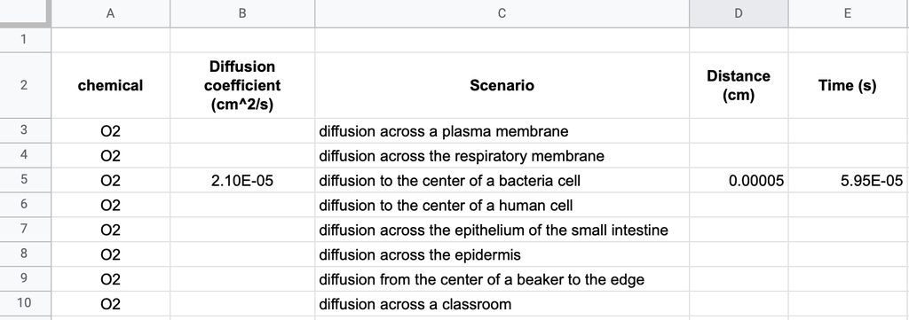

Figure 2.1: Partially filled table of scenarios for activity 1

2. Using the table, create a “scatterplot” with Distance on the x-axis and Time on the way axis - but only for the biological distances (not the beaker or classroom). Add a “power series” regression line (Google Sheets/Excel call this a “trend line”). Add the equation for the regression line to your plot. Think about the meaning of the exponent.
3. The exponential curve on the plot is very satisfactory (for understanding the relationship) but the points are not because they are bunched up on the left hand side. The data values differ by many **orders of magnitude** (multiples of 10), which is hard to plot on a **linear scale**. Change the X and Y axes to logarithmic. Now the points are satisfactory but the line is linear and unless one better knows logarithms, one might misconceive the increase in time with distance as linear. It’s not, it’s exponential. So return the plot to linear axes.
4. Create two new columns that are the base 10 logarithms of distance and time. We use base 10 here because it is pretty easy to understand the log-transformed values. For example a value of -6 is $10^{-6}$. Now create a new chart just like the first but 1) using the log-transformed distance and time AND for the regression line use “Linear”. Still add the equation for the line to your plot. What is the coefficient in front of the “x”?

## 2.3 Tips

1. For the distances, use a google search with relevant key words, such as “what is the size of a bacterial cell”.
2. Be careful with the source of the information you use to find these distances. One of the links for information about the respiratory membrane is *super wrong* (and obviously wrong to a biologist with lots of experience with the scale of biological stuff)
3. Be rigorous with units! The diffusion coefficient is in units of $cm^2/s$ so your distance unit needs to be in cm! I use a function inside the cell to convert the distance in whatever units to cm.

## 2.4 Additional background

[Diffusion Time Calculator](https://www.physiologyweb.com/calculators/diffusion_time_calculator.html) page

# 3 Google sheet tips for Activities 2 and 3

Understand how to “fill-down” and “fill-right” the content in spreadsheet cells (not biological cells!). **Fill** means to copy the content of a cell into new cells. Spreadsheets are clever and can fill down or right in special ways. Formulas in the copied cell are copied with **relative** references. This means if a formula in the source cell references the cell above it, the formula in the target (filled) cells all reference the cell above them and not the original referenced cell.

To fill-down a single cell into a column of values or fill-right a single cell into a row of values, highlight the cell, click the handle on the lower-right corner of the highlight box, and drag the handle down or to the right.

To fill-right a column of cells into a **matrix** of values, highlight the cells, click the handle on the lower-right corner of the highlight box, and drag the handle to the right.

To fill-down a row of cells into a **matrix** of values, highlight the cells, click the handle on the lower-right corner of the highlight box, and drag the handle down.

# 4 Activity 2 – Use a simulation to construct the relationship between distance and time

Activity 1 is a little unsatisfactory in that I just give you an equation for how diffusion distance is related to time. Let’s do a simulation to build some intuition about where this equation comes from.

## 4.1 How to do Activity 2

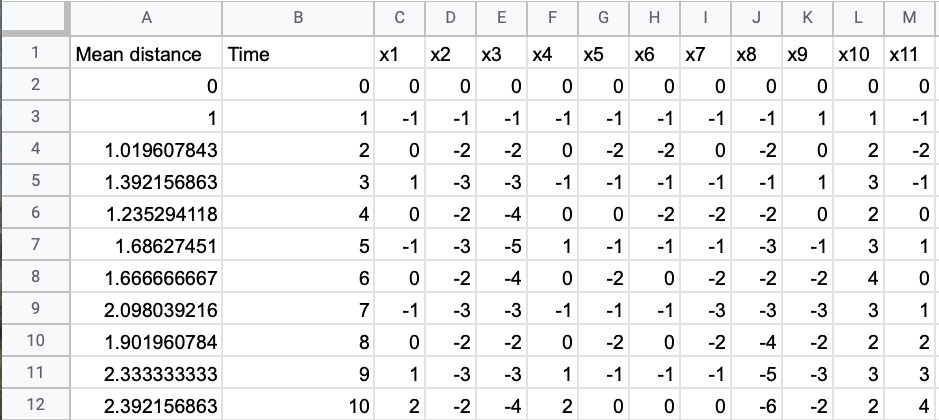

Figure 4.1: The upper left bit of my activity 2 sheet

On the second sheet, named “activity 2”

1. create one hundred 250-step random walks:
   1. create column labels like those in Figure 4.1.
   2. Each “x” column contains the 1-dimensional positions of a particle over time. You should simulate a system of about 100 particles, so create 100 “x” columns, labeled “x1”..“x100”. First, you will need to add enough columns to do this. For the x1..x100 labels, insert “x1” into cell C1. Highlight the cell and fill-right.
   3. Each row contains the positions of each particle at each time starting from time 0 (when the clock starts) to time 250. So, you should have about 251 rows with the values in the column “Time” given the values 0-250. To do this, insert a 0 into cell B2. Insert “=B2 + 1” into cell B3. Highlight cell B3 and fill-down to get time points 0…250. The units of time don’t matter.
   4. Insert a 0 for for Time 0 for particle x1. The initial position of the particle is the origin.
   5. In the Time 1 cell for particle x1, type "=C2 + round(rand())*2-1“. This function results in either a -1 or +1, each with probability of 50%. This is a”coin flip" function – think of -1 as “tails” and 1 as “heads”. The coin flip will determine the direction of this step: if -1, the particle takes one step backwards. If +1, the particle takes one step forwards.
   6. we then add this coin flip result to the current position, which is the value in the cell above.
   7. Now fill-down this equation for all times for particle x1. You have now simulated a 250 step **random walk** of a particle. Each cell contains the position of the particle at some time. The movement of the particle is entirely random – it is determined by a series of coin flips.
   8. Now, highlight all the number values in column x1 and fill-right across all the columns for x2..x100. You now have simulated random walks for 100 particles!
   9. Finally, in the column “Mean Distance”, compute the mean of the distance from the origin (zero) of the 100 particles at each of the 251 times (including time 0). The formula is “ArrayFormula(average(abs(C2:CX2)))”. Fill-down for all 251 time points. See the video for how to do this.

How does the function in step e work?

1. rand() generates a random, uniform number betwee 0 and 1.
2. round() takes the random number and rounds it, so the result is 0 or 1 with a 50% probability of each.
3. we then multiply the result times 2, so the new result is 0 or 2, each with a probability of 50%.
4. we then subtract one from the result, so the new result is -1 or 1, each with a probability of 50%.
2. Examine the time-distance relationship. Create a “scatterplot” with Mean Distance on the x-axis and Time on the y-axis. Add a “power series” regression line (Google Sheets/Excel call this a “trend line”). Add the equation for the regression line to your plot. What is the exponent? What do you think the **expected value** of the exponent is (this would be the value if you had an infinite number of particles, but you only have 100). Compare the exponent to that in Activity 1.

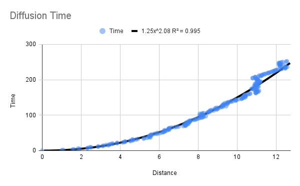

Figure 4.2: Average distance transported as a function of time (axes reversed to show Time as a function of distance).

3. Examine the random walks. Create a scatterplot of all x1..x100 random walks vs. Time. Time should be on the x-axis and each of the x1..x100 are series (the y-axis). See the video for how to do this. Think about the random walks and how the spread of the distance traveled (along the y-axis) inreases with time.

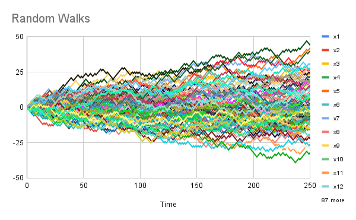

# 5 Activity 3 - Using simulation to show a system of diffusion across a membrane moving to equilibrium

On the third sheet, named “activity 3”, you will simulate a system of diffusion across a membrane moving to equilibrium using 250 particles tracked over 100 time steps. The membrane is at the origin (zero). Negative values are inside the cell. Positive values are outside the cell. At the start (Time 0), 10 of the 250 particles have a position of -1 and the remaining 240 have a position of +1.

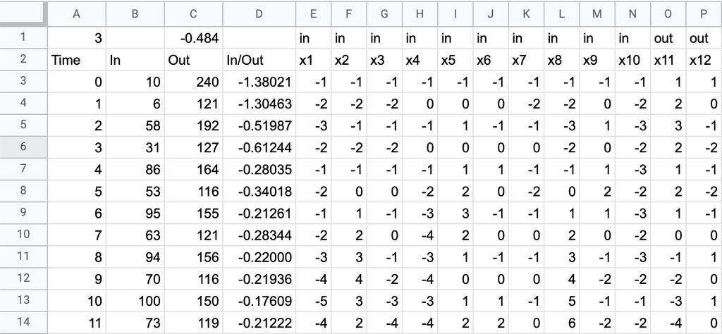

Figure 5.1: The top-left bit of my activity 3 sheet

1. create 250 “bounded” random walks
   1. Starting in row 2, create the column labels “Time”, “In”, “Out”, “In/Out”, “x1”
   2. Add ~ 250 columns to the right and fill “x1” to the right creating column labels x1…x250
   3. In row 1, insert “in” above x1 and fill-right to create 10 “in” cells. Above x11, insert “out” and fill-right to create 240 “out” cells.
   4. Insert a 0 in cell A3, which is the first cell under “Time”. In the cell beneath this, add the function “= A3 + 1”. Fill this cell down to get 100 time points.
   5. In cell E3, which is x1 at Time 0, add the function “= if(E1=”in“,-1,1)”. Fill right for all x1…x250. This function will seed the location of each of the 250 particles at Time 0, with -1 be next to the membrane and inside the cell and +1 being next to the membrane but outside of the cell.
   6. Now create 100 coin flips for all 250 particles. Go to cell A105 and create a column of 1..100. Starting in cell E105, add the coinflip function "= round(rand())*2-1" to all 101 time points for all 250 particles. Use the fill-down and fill-right method.
   7. In Cell E4, which is x1 at Time 1, add the function “= if(AND((E3+E105) <= 10, (E3+E105) >= -10),E3 + E105, if((E3+E105)>10,10, -10))”. Fill-down for all 100 post-baseline time points. Fill-right the column of 101 values across all 250 particles.

2. Count the particles on each side of the membrane
   1. In cell B3 (first cell below “in”), insert “=countif(E3:IT3,”<0“)”. This function counts the number of particles at Time 0 that have a value less than zero, and so are inside the membrane.
   2. In cell C3 (first cell below “out”), insert “=countif(E3:IT3,”>0“)”. This function counts the number of particles at Time 0 that have a value greater than zero, and so are outside the membrane.
   3. In cell D3 (first cell below “in/out”), insert “=log10(B3/C3)”. This is the log-ratio of particles inside the membrane to outside the membrane. We use log so that the scale is linear. Think about this. Without the log transformation, the equilbrium is 1 (the simplified ratio is 1/1). If there are 10x fewer particles in than out, the simplified ratio is 1/10 which is 9/10 away from the equilibrium value of 1. If there are 10x more particles in than out, the simplified ratio is 10/1 which is 9 away from 1. With the log-ratio, the equilbrium is zero, which is the log of 1/1. By log transforming, 10X fewer and 10X more are an equal distance from the equilibrium value of zero. Log10 of 1/10 is -1. Log10 of 10 is +1.
3. Examine how the log-ratio goes to equilibrium. Create a “smooth line plot” with log-ratio on the y-axis and Time on the x-axis. Think about “equilibrium”

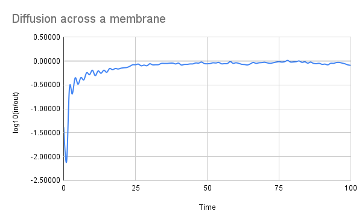

Figure 5.2: A system of 250 particles in diffusion across a membrane moving to equilibrium.

# 6 More Hints

## 6.1 understanding units

nano (eg. nm) - is $\frac{1}{10^9}$ or 1 billionth of something

micro (e.g. µs) is $\frac{1}{10^6}$ or 1 millionth of something

milli (e.g. mV) is $\frac{1}{10^3}$ or 1 thousandth of something

The abbreviation for micro is µ, which is the greek lowercase “mu”

Very often micrometers is shortened to “microns” so 23 microns = 23 µm.

## 6.2 understanding exponents

2.3E-5 means $2.3 \times 10^{-5}$

$10^{5}$ is 1 followed by 5 zeroes, or 100,000

$10^{-5}$ is 1 divided by the number one followed by 5 zeroes, or $\frac{1}{100,000}$